**Predicting Bankrupcy**

The goal is to build a model that can predict whether a company in Poland will go bankrupt or not

```python
import gzip
import json
import pickle
import matplotlib.pyplot as plt
import pandas as pd
import seaborn as sns

from sklearn.ensemble import RandomForestClassifier
from sklearn.ensemble import GradientBoostingClassifier
from imblearn.over_sampling import RandomOverSampler
from imblearn.under_sampling import RandomUnderSampler
from sklearn.impute import SimpleImputer
from sklearn.metrics import (
    ConfusionMatrixDisplay,
    classification_report,
    confusion_matrix,
)
from sklearn.model_selection import GridSearchCV, cross_val_score, train_test_split
from sklearn.pipeline import make_pipeline
from sklearn.tree import DecisionTreeClassifier
```

# Preparing the Data

## Importing

The data is available in a JSON file

```python
# Open file and load JSON
with open("poland-bankruptcy-data-2009.json", "r") as read_file:
    poland_data = json.load(read_file)
```

```python
# Print "poland_data" keys
poland_data.keys()
```

```
dict_keys(['schema', 'data', 'metadata'])
```

```python
# Printing the top data
poland_data["data"][0]
```

```
{'company_id': 1,
 'feat_1': 0.17419,
 'feat_2': 0.41299,
 'feat_3': 0.14371,
 'feat_4': 1.348,
 'feat_5': -28.982,
 'feat_6': 0.60383,
 'feat_7': 0.21946,
 'feat_8': 1.1225,
 'feat_9': 1.1961,
 'feat_10': 0.46359,
 'feat_11': 0.21946,
 'feat_12': 0.53139,
 'feat_13': 0.14233,
 'feat_14': 0.21946,
 'feat_15': 592.24,
 'feat_16': 0.6163,
 'feat_17': 2.4213,
 'feat_18': 0.21946,
 'feat_19': 0.12272,
 'feat_20': 37.573,
 'feat_21': 0.9969,
 'feat_22': 0.2951,
 'feat_23': 0.097402,
 'feat_24': 0.75641,
 'feat_25': 0.46359,
 'feat_26': 0.50669,
 'feat_27': 1.9737,
 'feat_28': 0.32417,
 'feat_29': 5.9473,
 'feat_30': 0.22493,
 'feat_31': 0.12272,
 'feat_32': 100.82,
 'feat_33': 3.6203,
 'feat_34': 0.71453,
 'feat_35': 0.2951,
 'feat_36': 1.8079,
 'feat_37': 123140.0,
 'feat_38': 0.46359,
 'feat_39': 0.16501,
```

[output cut: 11 more lines]

```
 'feat_51': 0.41299,
 'feat_52': 0.27622,
 'feat_53': 1.0457,
 'feat_54': 1.0458,
 'feat_55': 127280.0,
 'feat_56': 0.16396,
 'feat_57': 0.37574,
 'feat_58': 0.83604,
 'feat_59': 6.5269e-06,
 'feat_60': 9.7145,
 'feat_61': 6.2813,
 'feat_62': 84.291,
 'feat_63': 4.3303,
 'feat_64': 4.0341,
 'bankrupt': False}
```

```python
# Checking how many companies
len(poland_data["data"])
```

```
9977
```

```python
# Checking how many features
len(poland_data["data"][0])
```

```
66
```

Since it is a JSON file it is important to check if all companies have the same number of features

```python
# Iterate through companies
for item in poland_data["data"]:
    if len(item) != 66:
        print(" There are companies with a different number of features")
```

Creating a `DataFrame` `df` that contains the all companies in the dataset, indexed by `company_id`

```python
# Turn dictionary into DataFrame
df = pd.DataFrame().from_dict(poland_data["data"]).set_index("company_id")
print(df.shape)
df.head()
```

```
(9977, 65)
```

| company_id | feat_1 | feat_2 | feat_3 | feat_4 | feat_5 | feat_6 | feat_7 | feat_8 | feat_9 | feat_10 | ... | feat_56 | feat_57 | feat_58 | feat_59 | feat_60 | feat_61 | feat_62 | feat_63 | feat_64 | bankrupt |
| --- | --- | --- | --- | --- | --- | --- | --- | --- | --- | --- | --- | --- | --- | --- | --- | --- | --- | --- | --- | --- | --- |
| 1 | 0.174190 | 0.41299 | 0.14371 | 1.3480 | -28.9820 | 0.60383 | 0.219460 | 1.12250 | 1.1961 | 0.46359 | ... | 0.163960 | 0.375740 | 0.83604 | 0.000007 | 9.7145 | 6.2813 | 84.291 | 4.3303 | 4.0341 | False |
| 2 | 0.146240 | 0.46038 | 0.28230 | 1.6294 | 2.5952 | 0.00000 | 0.171850 | 1.17210 | 1.6018 | 0.53962 | ... | 0.027516 | 0.271000 | 0.90108 | 0.000000 | 5.9882 | 4.1103 | 102.190 | 3.5716 | 5.9500 | False |
| 3 | 0.000595 | 0.22612 | 0.48839 | 3.1599 | 84.8740 | 0.19114 | 0.004572 | 2.98810 | 1.0077 | 0.67566 | ... | 0.007639 | 0.000881 | 0.99236 | 0.000000 | 6.7742 | 3.7922 | 64.846 | 5.6287 | 4.4581 | False |
| 5 | 0.188290 | 0.41504 | 0.34231 | 1.9279 | -58.2740 | 0.00000 | 0.233580 | 1.40940 | 1.3393 | 0.58496 | ... | 0.176480 | 0.321880 | 0.82635 | 0.073039 | 2.5912 | 7.0756 | 100.540 | 3.6303 | 4.6375 | False |
| 6 | 0.182060 | 0.55615 | 0.32191 | 1.6045 | 16.3140 | 0.00000 | 0.182060 | 0.79808 | 1.8126 | 0.44385 | ... | 0.555770 | 0.410190 | 0.46957 | 0.029421 | 8.4553 | 3.3488 | 107.240 | 3.4036 | 12.4540 | False |

5 rows × 65 columns

To make the whole process easier I will be creating a function to wrangle the data

```python
def wrangle(filename):

    """
    Read a JSON file into a 'DataFrame'.

    Returns treated Data in a pandas DataFrame

    Parameters
    ----------
    filename: str
        name of the file to be read
    """

    # Open file and load JSON
    with open(filename, "r") as f:
        data = json.load(f)

    # Turn dictionary into DataFrame
    df = pd.DataFrame().from_dict(data["data"]).set_index("company_id")

    return df
```

```python
df = wrangle("poland-bankruptcy-data-2009.json")
print(df.shape)
df.head()
```

```
(9977, 65)
```

| company_id | feat_1 | feat_2 | feat_3 | feat_4 | feat_5 | feat_6 | feat_7 | feat_8 | feat_9 | feat_10 | ... | feat_56 | feat_57 | feat_58 | feat_59 | feat_60 | feat_61 | feat_62 | feat_63 | feat_64 | bankrupt |
| --- | --- | --- | --- | --- | --- | --- | --- | --- | --- | --- | --- | --- | --- | --- | --- | --- | --- | --- | --- | --- | --- |
| 1 | 0.174190 | 0.41299 | 0.14371 | 1.3480 | -28.9820 | 0.60383 | 0.219460 | 1.12250 | 1.1961 | 0.46359 | ... | 0.163960 | 0.375740 | 0.83604 | 0.000007 | 9.7145 | 6.2813 | 84.291 | 4.3303 | 4.0341 | False |
| 2 | 0.146240 | 0.46038 | 0.28230 | 1.6294 | 2.5952 | 0.00000 | 0.171850 | 1.17210 | 1.6018 | 0.53962 | ... | 0.027516 | 0.271000 | 0.90108 | 0.000000 | 5.9882 | 4.1103 | 102.190 | 3.5716 | 5.9500 | False |
| 3 | 0.000595 | 0.22612 | 0.48839 | 3.1599 | 84.8740 | 0.19114 | 0.004572 | 2.98810 | 1.0077 | 0.67566 | ... | 0.007639 | 0.000881 | 0.99236 | 0.000000 | 6.7742 | 3.7922 | 64.846 | 5.6287 | 4.4581 | False |
| 5 | 0.188290 | 0.41504 | 0.34231 | 1.9279 | -58.2740 | 0.00000 | 0.233580 | 1.40940 | 1.3393 | 0.58496 | ... | 0.176480 | 0.321880 | 0.82635 | 0.073039 | 2.5912 | 7.0756 | 100.540 | 3.6303 | 4.6375 | False |
| 6 | 0.182060 | 0.55615 | 0.32191 | 1.6045 | 16.3140 | 0.00000 | 0.182060 | 0.79808 | 1.8126 | 0.44385 | ... | 0.555770 | 0.410190 | 0.46957 | 0.029421 | 8.4553 | 3.3488 | 107.240 | 3.4036 | 12.4540 | False |

5 rows × 65 columns

```python
# Inspect DataFrame
df.info()
```

```
<class 'pandas.core.frame.DataFrame'>
Int64Index: 9977 entries, 1 to 10503
Data columns (total 65 columns):
 #   Column    Non-Null Count  Dtype
---  ------    --------------  -----
 0   feat_1    9977 non-null   float64
 1   feat_2    9977 non-null   float64
 2   feat_3    9977 non-null   float64
 3   feat_4    9960 non-null   float64
 4   feat_5    9952 non-null   float64
 5   feat_6    9977 non-null   float64
 6   feat_7    9977 non-null   float64
 7   feat_8    9964 non-null   float64
 8   feat_9    9974 non-null   float64
 9   feat_10   9977 non-null   float64
```

[output cut: 57 more lines]

Checking how many companies in the dataset went bankrupt

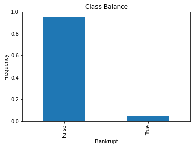

```python
# Plot class balance
df["bankrupt"].value_counts(normalize=True).plot(
    kind="bar",
    xlabel="Bankrupt",
    ylabel="Frequency",
    title="Class Balance"
);
```

The plot shows an imbalanced dataset, where the majority class is far bigger than the minority class

Feature 27 (`feat_27`) shows the profit on operating activities / financial expenses ratio

With a boxplot the plot will show the distribution of "feat_27" column

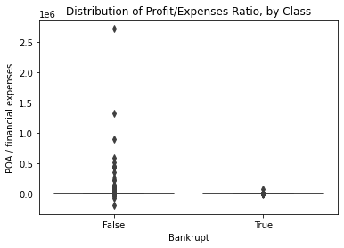

```python
# Create boxplot
sns.boxplot(x="bankrupt", y="feat_27", data=df)

# Update axis and title details
plt.xlabel("Bankrupt")
plt.ylabel("POA / financial expenses")
plt.title("Distribution of Profit/Expenses Ratio, by Class");
```

This time it seems the plot does not help that much, some outliers are really off

```python
# Summary statistics for `feat_27
df["feat_27"].describe()
```

```
count    9.312000e+03
mean     1.206467e+03
std      3.547726e+04
min     -1.901300e+05
25%      0.000000e+00
50%      1.064300e+00
75%      4.788275e+00
max      2.723000e+06
Name: feat_27, dtype: float64
```

I tend to avoid to present scientific notation since it is, most of the time, not easy to read

```python
# Summary statistics for `feat_27 and supressing scientific notation
df["feat_27"].describe().apply("{0:,.0f}".format)
```

```
count        9,312
mean         1,206
std         35,477
min       -190,130
25%              0
50%              1
75%              5
max      2,723,000
Name: feat_27, dtype: object
```

The median is around 1, but the mean is over 1000. That suggests that this feature is most likely skewed. Making a histogram to see what the distribution actually looks like is ideal

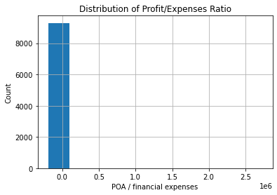

```python
# Plot histogram of `feat_27`
df["feat_27"].hist()

# Update axis and title details
plt.xlabel("POA / financial expenses")
plt.ylabel("Count"),
plt.title("Distribution of Profit/Expenses Ratio");
```

Tring a regular outlier treatment approach

```python
# Quantile filtering
q1, q9 = df["feat_27"].quantile([0.1, 0.9])
mask = df["feat_27"].between(q1, q9)
```

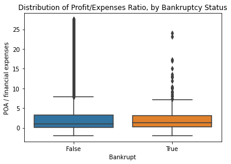

```python
# Create clipped boxplot
q1, q9 = df["feat_27"].quantile([0.1, 0.9])
mask = df["feat_27"].between(q1,q9)
sns.boxplot(x="bankrupt", y="feat_27", data=df[mask])

# Update axis and title details
plt.xlabel("Bankrupt")
plt.ylabel("POA / financial expenses")
plt.title("Distribution of Profit/Expenses Ratio, by Bankruptcy Status");
```

Exploring another feature, feature 55 (`feat_55`) which is the working capital

```python
# Explore another feature
df["feat_55"].describe().apply("{0:,.0f}".format)
```

```
count        9,977
mean         6,772
std         61,215
min       -751,380
25%             13
50%            887
75%          4,363
max      3,380,500
Name: feat_55, dtype: object
```

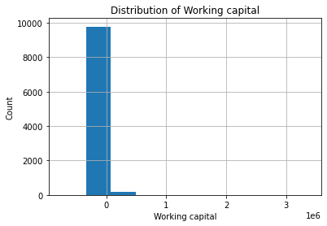

```python
# Plot histogram of `feat_55`
df["feat_55"].hist()

# Update axis and title details
plt.xlabel("Working capital")
plt.ylabel("Count"),
plt.title("Distribution of Working capital");
```

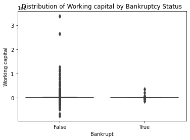

```python
# Create boxplot
sns.boxplot(x="bankrupt", y="feat_55", data=df)

# Update axis and title details
plt.xlabel("Bankrupt")
plt.ylabel("Working capital")
plt.title("Distribution of Working capital by Bankruptcy Status");
```

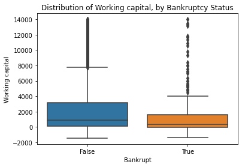

```python
# Create clipped boxplot
q1, q9 = df["feat_55"].quantile([0.1, 0.9])
mask = df["feat_55"].between(q1,q9)
sns.boxplot(x="bankrupt", y="feat_55", data=df[mask])
plt.xlabel("Bankrupt")
plt.ylabel("Working capital")
plt.title("Distribution of Working capital, by Bankruptcy Status");
```

This feature is also skewed. I will be exploring one more

```python
# Explore another feature
df["feat_45"].describe().apply("{0:,.0f}".format)
```

```
count      9,416
mean          18
std        1,765
min      -74,385
25%            0
50%            0
75%            1
max      113,280
Name: feat_45, dtype: object
```

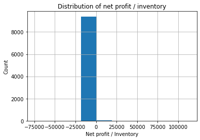

```python
# Plot histogram of `feat_55`
df["feat_45"].hist()

# Update axis and title details
plt.xlabel("Net profit / Inventory")
plt.ylabel("Count"),
plt.title("Distribution of net profit / inventory");
```

[figure not shown]

```python
# Create boxplot
sns.boxplot(x="bankrupt", y="feat_55", data=df)

# Update axis and title details
plt.xlabel("Bankrupt")
plt.ylabel("Net profit / Inventory")
plt.title("Distribution of Net profit / Inventory by Bankruptcy Status");
```

[figure not shown]

```python
# Create clipped boxplot
q1, q9 = df["feat_55"].quantile([0.1, 0.9])
mask = df["feat_55"].between(q1,q9)
sns.boxplot(x="bankrupt", y="feat_55", data=df[mask])
plt.xlabel("Bankrupt")
plt.ylabel("Net profit / Inventory")
plt.title("Distribution of Net profit / Inventory, by Bankruptcy Status");
```

Looking at other features, it is noticeable that they are skewed too. This will be important to keep in mind when deciding what type of model is more adequate to use

Another important consideration for model selection is whether there are any issues with multicollinearity, a heatmap for a quick look is ideal

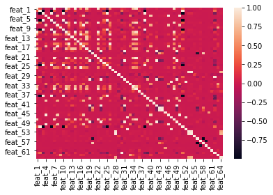

```python
corr = df.drop(columns="bankrupt").corr()
sns.heatmap(corr);
```

A few outtakes can be taken from the initial EDA. First, the data is imbalanced. This is something to address in the data preparation. Second, many of the features have missing values that need to be impute. And since the features are highly skewed, the best imputation strategy is likely median, not mean. Finally, there are autocorrelation issues, which means that linear models will not be efficient. A tree-based model it is for now.

# Split

```python
target = "bankrupt"
X = df.drop(columns=target)
y = df[target]

print("X shape:", X.shape)
print("y shape:", y.shape)
```

```
X shape: (9977, 64)
y shape: (9977,)
```

In order to make sure that the model can generalize, it is necessary to put aside a test set that will be used to evaluate the model once it is trained

```python
X_train, X_test, y_train, y_test = train_test_split(
    X, y, test_size=0.2, random_state=42
)

print("X_train shape:", X_train.shape)
print("y_train shape:", y_train.shape)
print("X_test shape:", X_test.shape)
print("y_test shape:", y_test.shape)
```

```
X_train shape: (7981, 64)
y_train shape: (7981,)
X_test shape: (1996, 64)
y_test shape: (1996,)
```

Before building the model it is necessary to address the class imbalance noticed during EDA. One strategy is to resample the training data. There are different approaches to tackle this problem, I will be starting with **under-sampling**:

```python
# Instantiation
under_sampler = RandomUnderSampler(random_state=42)
# Fit
X_train_under, y_train_under = under_sampler.fit_resample(X_train, y_train)
print(X_train_under.shape)
X_train_under.head()
```

```
(768, 64)
```

|  | feat_1 | feat_2 | feat_3 | feat_4 | feat_5 | feat_6 | feat_7 | feat_8 | feat_9 | feat_10 | ... | feat_55 | feat_56 | feat_57 | feat_58 | feat_59 | feat_60 | feat_61 | feat_62 | feat_63 | feat_64 |
| --- | --- | --- | --- | --- | --- | --- | --- | --- | --- | --- | --- | --- | --- | --- | --- | --- | --- | --- | --- | --- | --- |
| 0 | 0.121400 | 0.097238 | 0.74500 | 8.66160 | 25.8370 | 0.000000 | 0.158840 | 9.284100 | 2.7588 | 0.902760 | ... | 775.71 | 0.075999 | 0.13447 | 0.94243 | 0.000000 | 4.9049 | 11.3390 | 12.865 | 28.3720 | 17.4870 |
| 1 | 0.316280 | 0.264920 | 0.65346 | 3.46660 | 55.1890 | 0.290140 | 0.316280 | 2.774700 | 2.4721 | 0.735080 | ... | 1367.90 | 0.119990 | 0.43027 | 0.87412 | 0.000000 | 10.6020 | 4.5533 | 39.115 | 9.3314 | 30.2870 |
| 2 | 0.066615 | 0.890270 | -0.48007 | 0.46076 | -76.3080 | 0.047487 | 0.087936 | -0.011406 | 1.0952 | -0.010155 | ... | -46566.00 | 0.086894 | -6.56010 | 0.91311 | 0.000000 | 32.0280 | 10.0480 | 105.220 | 3.4689 | 5.2362 |
| 3 | 0.208000 | 0.363630 | 0.33875 | 1.93160 | -5.3169 | 0.251870 | 0.258280 | 1.603300 | 1.0535 | 0.583020 | ... | 187050.00 | 0.050746 | 0.35676 | 0.94925 | 0.000000 | 34.8840 | 19.0030 | 24.498 | 14.8990 | 18.2040 |
| 4 | 0.096863 | 0.299320 | 0.35393 | 2.42640 | 31.5630 | 0.267550 | 0.125130 | 2.341000 | 1.0495 | 0.700680 | ... | 2993.00 | 0.047123 | 0.13824 | 0.95288 | 0.073041 | 13.7820 | 6.8621 | 39.668 | 9.2013 | 5.7376 |

5 rows × 64 columns

```python
y_train_under.value_counts(normalize=True)
```

```
False    0.5
True     0.5
Name: bankrupt, dtype: float64
```

Another approach is the **over-sampling** technique:

```python
# Instantiation
over_sampler = RandomOverSampler(random_state=42)
#Fit
X_train_over, y_train_over = over_sampler.fit_resample(X_train, y_train)
print(X_train_over.shape)
X_train_over.head()
```

```
(15194, 64)
```

|  | feat_1 | feat_2 | feat_3 | feat_4 | feat_5 | feat_6 | feat_7 | feat_8 | feat_9 | feat_10 | ... | feat_55 | feat_56 | feat_57 | feat_58 | feat_59 | feat_60 | feat_61 | feat_62 | feat_63 | feat_64 |
| --- | --- | --- | --- | --- | --- | --- | --- | --- | --- | --- | --- | --- | --- | --- | --- | --- | --- | --- | --- | --- | --- |
| 0 | 0.279320 | 0.053105 | 0.852030 | 17.0440 | 199.080 | 0.741770 | 0.353570 | 16.00600 | 1.2346 | 0.84997 | ... | 52857.00 | 0.190040 | 0.328630 | 0.80996 | 0.00000 | NaN | 4.1858 | 11.002 | 33.1760 | 18.5720 |
| 1 | 0.001871 | 0.735120 | 0.156460 | 1.2269 | -10.837 | 0.000000 | 0.002938 | 0.36032 | 1.4809 | 0.26488 | ... | 440.02 | 0.014794 | 0.007064 | 0.99803 | 0.00000 | 7.4268 | 2.2925 | 169.960 | 2.1476 | 9.6185 |
| 2 | 0.113940 | 0.490250 | 0.077121 | 1.2332 | -43.184 | -0.000171 | 0.113940 | 1.03980 | 1.1649 | 0.50975 | ... | 4617.40 | 0.214890 | 0.223520 | 0.78761 | 0.27412 | 6.2791 | 6.1622 | 103.630 | 3.5220 | 1.9673 |
| 3 | 0.008136 | 0.652610 | 0.148120 | 1.2628 | 29.071 | 0.000000 | 0.008136 | 0.53230 | 1.2891 | 0.34739 | ... | 920.98 | 0.045169 | 0.023421 | 0.99434 | 0.14403 | 22.7480 | 2.2673 | 159.580 | 2.2872 | 4.4718 |
| 4 | 0.045396 | 0.279640 | 0.708730 | 3.7656 | 238.120 | 0.000000 | 0.056710 | 2.57610 | 1.0169 | 0.72036 | ... | 10744.00 | 0.047501 | 0.063019 | 0.94624 | 0.00000 | 13.8860 | 49.0660 | 91.984 | 3.9681 | 29.0460 |

5 rows × 64 columns

```python
y_train_over.value_counts(normalize=True)
```

```
False    0.5
True     0.5
Name: bankrupt, dtype: float64
```

# Build Model

## Baseline

Establishing the baseline for the model. Since this is a classification problem, I will be using accuracy score.

```python
acc_baseline = y_train.value_counts(normalize=True).max()
print("Baseline Accuracy:", round(acc_baseline, 4))
```

```
Baseline Accuracy: 0.9519
```

Because the classes are imbalanced, the baseline accuracy is very high. It is important to keep this in mind because, even if the trained model gets a high validation accuracy score, that does not mean it is actually good.

Creating three identical models `model_reg`, `model_under` and `model_over`

```python
# Fit on `X_train`, `y_train`
model_reg = make_pipeline(
    SimpleImputer(strategy="median"), DecisionTreeClassifier(random_state=42)
)
model_reg.fit(X_train, y_train)

# Fit on `X_train_under`, `y_train_under`
model_under = make_pipeline(
    SimpleImputer(strategy="median"), DecisionTreeClassifier(random_state=42)
)
model_under.fit(X_train_under, y_train_under)

# Fit on `X_train_over`, `y_train_over`
model_over = make_pipeline(
    SimpleImputer(strategy="median"), DecisionTreeClassifier(random_state=42)
)
model_over.fit(X_train_over, y_train_over)
```

```
Pipeline(steps=[('simpleimputer', SimpleImputer(strategy='median')),
                ('decisiontreeclassifier',
                 DecisionTreeClassifier(random_state=42))])
```

# Evaluating

```python
for m in [model_reg, model_under, model_over]:
    acc_train = m.score(X_train, y_train)
    acc_test = m.score(X_test, y_test)

    print("Training Accuracy:", round(acc_train, 4))
    print("Test Accuracy:", round(acc_test, 4))
```

```
Training Accuracy: 1.0
Test Accuracy: 0.9359
Training Accuracy: 0.7421
Test Accuracy: 0.7104
Training Accuracy: 1.0
Test Accuracy: 0.9344
```

Clearly the model with the `under-sampling` approach performed the worst. The other two approaches were quite similar

Good accuracy scores do not tell much about the model's performance when dealing with imbalanced data. So instead of looking at what the model got right or wrong, looking at what predictions differ for the two classes in the dataset is ideal

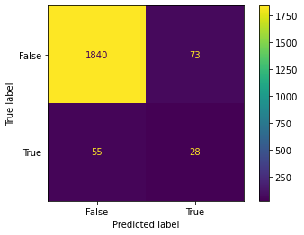

```python
# Plot confusion matrix for the regular model
ConfusionMatrixDisplay.from_estimator(model_reg, X_test, y_test);
```

With the confusion matrix it is possible to see that although the model is predicting the True Falses very well it is not predicting True Positives that well

It is also possible to evaluate the model using precision and recall. The precision score is important when it is desirable for the model to only predict that a company will go bankrupt if its very confident in its prediction. The recall score is important if there is a need to identify all the companies that will go bankrupt, even if that means being incorrect sometimes.

```python
# Print classification report
print(classification_report(y_test, model_reg.predict(X_test)))
```

```
              precision    recall  f1-score   support

       False       0.97      0.96      0.97      1913
        True       0.28      0.34      0.30        83

    accuracy                           0.94      1996
   macro avg       0.62      0.65      0.64      1996
weighted avg       0.94      0.94      0.94      1996
```

Models that predict a single outcome are definitely useful but are not always the optimum option. It is definitely a useful way to predict the future, but when using more than one model simultaneously, it is possible to have a more trustworthy prediction. **Ensemble** models work by building multiple models on random subsets of the same data, and then comparing their predictions to make a final prediction. That is one of the reasons that a random forest may be the best option for now

```python
# Creating a pipeline with a "RandomForestClassifier" and a "SimpleImputer"
clf = make_pipeline(SimpleImputer(), RandomForestClassifier(random_state=42))
print(clf)
```

```
Pipeline(steps=[('simpleimputer', SimpleImputer()),
                ('randomforestclassifier',
                 RandomForestClassifier(random_state=42))])
```

Performing cross-validation with the classifier, using the over-sampled training data. Using five folds and maximum computing power available

```python
cv_acc_scores = cross_val_score(clf, X_train_over, y_train_over, cv=5, n_jobs=-1)
print(cv_acc_scores)
```

```
[0.99670944 0.99835472 0.99769661 0.9970385  0.99901251]
```

In order to get the best performance from the model, it is necessary to tune its hyperparameter

```python
params = {
    "simpleimputer__strategy": ["mean", "median"],
    "randomforestclassifier__n_estimators": range(25, 100, 25),
    "randomforestclassifier__max_depth": range(10, 50, 10)
}
params
```

```
{'simpleimputer__strategy': ['mean', 'median'],
 'randomforestclassifier__n_estimators': range(25, 100, 25),
 'randomforestclassifier__max_depth': range(10, 50, 10)}
```

```python
# GridSearchCV instantiation
model = GridSearchCV(
    clf,
    param_grid=params,
    cv=5,
    n_jobs=-1,
    verbose=1
)
model
```

```
GridSearchCV(cv=5,
             estimator=Pipeline(steps=[('simpleimputer', SimpleImputer()),
                                       ('randomforestclassifier',
                                        RandomForestClassifier(random_state=42))]),
             n_jobs=-1,
             param_grid={'randomforestclassifier__max_depth': range(10, 50, 10),
                         'randomforestclassifier__n_estimators': range(25, 100, 25),
                         'simpleimputer__strategy': ['mean', 'median']},
             verbose=1)
```

```python
# Train model
model.fit(X_train_over, y_train_over)
```

```
Fitting 5 folds for each of 24 candidates, totalling 120 fits
```

```
GridSearchCV(cv=5,
             estimator=Pipeline(steps=[('simpleimputer', SimpleImputer()),
                                       ('randomforestclassifier',
                                        RandomForestClassifier(random_state=42))]),
             n_jobs=-1,
             param_grid={'randomforestclassifier__max_depth': range(10, 50, 10),
                         'randomforestclassifier__n_estimators': range(25, 100, 25),
                         'simpleimputer__strategy': ['mean', 'median']},
             verbose=1)
```

Since there are too many results to look at, the best approach will be to transform them into a DataFrame

```python
cv_results = pd.DataFrame(model.cv_results_)
cv_results.head(10)
```

|  | mean_fit_time | std_fit_time | mean_score_time | std_score_time | param_randomforestclassifier__max_depth | param_randomforestclassifier__n_estimators | param_simpleimputer__strategy | params | split0_test_score | split1_test_score | split2_test_score | split3_test_score | split4_test_score | mean_test_score | std_test_score | rank_test_score |
| --- | --- | --- | --- | --- | --- | --- | --- | --- | --- | --- | --- | --- | --- | --- | --- | --- |
| 0 | 1.189274 | 0.058734 | 0.021401 | 0.000490 | 10 | 25 | mean | {'randomforestclassifier__max_depth': 10, 'ran... | 0.979269 | 0.977295 | 0.977953 | 0.980915 | 0.982225 | 0.979532 | 0.001829 | 21 |
| 1 | 1.236798 | 0.028976 | 0.023157 | 0.003251 | 10 | 25 | median | {'randomforestclassifier__max_depth': 10, 'ran... | 0.978611 | 0.969069 | 0.975650 | 0.970056 | 0.974984 | 0.973674 | 0.003586 | 24 |
| 2 | 2.138076 | 0.025647 | 0.036831 | 0.003616 | 10 | 50 | mean | {'randomforestclassifier__max_depth': 10, 'ran... | 0.983218 | 0.979599 | 0.978282 | 0.984534 | 0.983871 | 0.981901 | 0.002488 | 20 |
| 3 | 2.234510 | 0.006709 | 0.035001 | 0.001549 | 10 | 50 | median | {'randomforestclassifier__max_depth': 10, 'ran... | 0.980257 | 0.971043 | 0.978940 | 0.978282 | 0.977617 | 0.977228 | 0.003213 | 23 |
| 4 | 3.271262 | 0.097160 | 0.049074 | 0.001434 | 10 | 75 | mean | {'randomforestclassifier__max_depth': 10, 'ran... | 0.984205 | 0.980586 | 0.976966 | 0.984534 | 0.984529 | 0.982164 | 0.002996 | 19 |
| 5 | 3.298397 | 0.098928 | 0.052938 | 0.007816 | 10 | 75 | median | {'randomforestclassifier__max_depth': 10, 'ran... | 0.980915 | 0.972688 | 0.981573 | 0.979928 | 0.981567 | 0.979334 | 0.003377 | 22 |
| 6 | 1.373231 | 0.047173 | 0.025000 | 0.002757 | 20 | 25 | mean | {'randomforestclassifier__max_depth': 20, 'ran... | 0.996380 | 0.997038 | 0.995722 | 0.995393 | 0.997367 | 0.996380 | 0.000750 | 17 |
| 7 | 1.465321 | 0.072767 | 0.023801 | 0.000748 | 20 | 25 | median | {'randomforestclassifier__max_depth': 20, 'ran... | 0.995722 | 0.996709 | 0.997368 | 0.996380 | 0.998025 | 0.996841 | 0.000795 | 14 |
| 8 | 2.412429 | 0.012068 | 0.038841 | 0.000424 | 20 | 50 | mean | {'randomforestclassifier__max_depth': 20, 'ran... | 0.996709 | 0.996709 | 0.995722 | 0.995064 | 0.997367 | 0.996314 | 0.000816 | 18 |
| 9 | 2.540339 | 0.016055 | 0.040048 | 0.002077 | 20 | 50 | median | {'randomforestclassifier__max_depth': 20, 'ran... | 0.996051 | 0.997368 | 0.998026 | 0.996709 | 0.998354 | 0.997302 | 0.000843 | 11 |

In addition to the accuracy scores for all the different models tried during the grid search, it is possible to see how long it took each model to train.

Taking a closer look at how different hyperparameter settings affect training time.

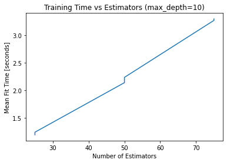

```python
# Create mask
mask = cv_results["param_randomforestclassifier__max_depth"] == 10
# Plot fit time vs n_estimators
plt.plot(
    cv_results[mask]["param_randomforestclassifier__n_estimators"],
    cv_results[mask]["mean_fit_time"]
)
# Label axes
plt.xlabel("Number of Estimators")
plt.ylabel("Mean Fit Time [seconds]")
plt.title("Training Time vs Estimators (max_depth=10)");
```

[figure not shown]

```python
# Create mask
mask = cv_results["param_randomforestclassifier__n_estimators"] == 25
# Plot fit time vs max_depth
plt.plot(
    cv_results[mask]["param_randomforestclassifier__n_estimators"],
    cv_results[mask]["mean_fit_time"]
)
# Label axes
plt.xlabel("Max Depth")
plt.ylabel("Mean Fit Time [seconds]")
plt.title("Training Time vs Max Depth (n_estimators=25)");
```

In a model building proccess it is interesting to keep an eye on the computational time of models

```python
# Extract best hyperparameters
model.best_params_
```

```
{'randomforestclassifier__max_depth': 40,
 'randomforestclassifier__n_estimators': 50,
 'simpleimputer__strategy': 'median'}
```

Evaluating the best model

```python
acc_train = model.score(X_train, y_train)
acc_test = model.score(X_test, y_test)

print("Training Accuracy:", round(acc_train, 4))
print("Test Accuracy:", round(acc_test, 4))
```

```
Training Accuracy: 1.0
Test Accuracy: 0.9589
```

```python
y_test.value_counts()
```

```
False    1913
True       83
Name: bankrupt, dtype: int64
```

```python
# Print classification report
print(classification_report(y_test, model.predict(X_test)))
```

```
              precision    recall  f1-score   support

       False       0.96      0.99      0.98      1913
        True       0.52      0.14      0.23        83

    accuracy                           0.96      1996
   macro avg       0.74      0.57      0.60      1996
weighted avg       0.95      0.96      0.95      1996
```

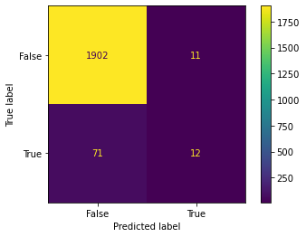

```python
# Plot confusion matrix
ConfusionMatrixDisplay.from_estimator(model, X_test, y_test);
```

Creating a horizontal bar chart with the 10 most important features for the model

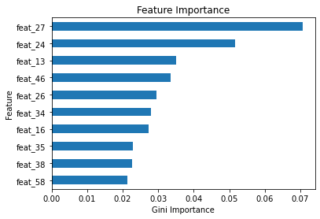

```python
# Get feature names from training data
features = X_train_over.columns
# Extract importances from model
importances = model.best_estimator_.named_steps["randomforestclassifier"].feature_importances_
# Create a series with feature names and importances
feat_imp = pd.Series(importances, index=features).sort_values()
# Plot 10 most important features
feat_imp.tail(10).plot(kind="barh")
plt.xlabel("Gini Importance")
plt.ylabel("Feature")
plt.title("Feature Importance");
```

The chosen model will always depend on what problem it is being tackled at the moment. In a scenario where a company would like to know the best assertiveness on who is more likely to go bankrupt this model would not perform too well because its recall True recall value is not high

This time I will be using a `GradientBoostingClassifier` model

```python
clf = make_pipeline(SimpleImputer(), GradientBoostingClassifier())
```

In order to get the best performance from the model, it is necessary to tune its hyperparameter

```python
params = {
    "simpleimputer__strategy": ["mean", "median"],
    "gradientboostingclassifier__n_estimators": range(20, 31, 5),
    "gradientboostingclassifier__max_depth": range(2, 5)
}
params
```

```
{'simpleimputer__strategy': ['mean', 'median'],
 'gradientboostingclassifier__n_estimators': range(20, 31, 5),
 'gradientboostingclassifier__max_depth': range(2, 5)}
```

```python
# GridSearchCV instantiation
model = GridSearchCV(clf, param_grid=params, cv=5, n_jobs=-1, verbose=1)
```

```python
# Fit model to over-sampled training data
model.fit(X_train_over, y_train_over)
```

```
Fitting 5 folds for each of 18 candidates, totalling 90 fits
```

```
GridSearchCV(cv=5,
             estimator=Pipeline(steps=[('simpleimputer', SimpleImputer()),
                                       ('gradientboostingclassifier',
                                        GradientBoostingClassifier())]),
             n_jobs=-1,
             param_grid={'gradientboostingclassifier__max_depth': range(2, 5),
                         'gradientboostingclassifier__n_estimators': range(20, 31, 5),
                         'simpleimputer__strategy': ['mean', 'median']},
             verbose=1)
```

```python
results = pd.DataFrame(model.cv_results_)
results.sort_values("rank_test_score").head(10)
```

|  | mean_fit_time | std_fit_time | mean_score_time | std_score_time | param_gradientboostingclassifier__max_depth | param_gradientboostingclassifier__n_estimators | param_simpleimputer__strategy | params | split0_test_score | split1_test_score | split2_test_score | split3_test_score | split4_test_score | mean_test_score | std_test_score | rank_test_score |
| --- | --- | --- | --- | --- | --- | --- | --- | --- | --- | --- | --- | --- | --- | --- | --- | --- |
| 16 | 7.128310 | 0.125059 | 0.010305 | 0.000403 | 4 | 30 | mean | {'gradientboostingclassifier__max_depth': 4, '... | 0.930240 | 0.913129 | 0.913458 | 0.925962 | 0.911455 | 0.918849 | 0.007705 | 1 |
| 17 | 7.113522 | 0.096315 | 0.011418 | 0.002323 | 4 | 30 | median | {'gradientboostingclassifier__max_depth': 4, '... | 0.915433 | 0.897006 | 0.909181 | 0.915762 | 0.911455 | 0.909767 | 0.006842 | 2 |
| 14 | 5.925436 | 0.078809 | 0.010000 | 0.000632 | 4 | 25 | mean | {'gradientboostingclassifier__max_depth': 4, '... | 0.916420 | 0.899638 | 0.898322 | 0.909181 | 0.895655 | 0.903843 | 0.007770 | 3 |
| 15 | 6.067199 | 0.097189 | 0.014715 | 0.008175 | 4 | 25 | median | {'gradientboostingclassifier__max_depth': 4, '... | 0.906219 | 0.889108 | 0.895031 | 0.897993 | 0.902238 | 0.898118 | 0.005888 | 4 |
| 12 | 4.956630 | 0.137772 | 0.009684 | 0.000410 | 4 | 20 | mean | {'gradientboostingclassifier__max_depth': 4, '... | 0.901612 | 0.888450 | 0.884501 | 0.896677 | 0.872284 | 0.888705 | 0.010174 | 5 |
| 13 | 5.084908 | 0.099626 | 0.010275 | 0.000680 | 4 | 20 | median | {'gradientboostingclassifier__max_depth': 4, '... | 0.892399 | 0.878578 | 0.885160 | 0.879237 | 0.883476 | 0.883770 | 0.004980 | 6 |
| 10 | 6.028591 | 0.051339 | 0.012401 | 0.002498 | 3 | 30 | mean | {'gradientboostingclassifier__max_depth': 3, '... | 0.874630 | 0.877591 | 0.869365 | 0.866074 | 0.866359 | 0.870804 | 0.004580 | 7 |
| 8 | 4.523298 | 0.101340 | 0.009800 | 0.000748 | 3 | 25 | mean | {'gradientboostingclassifier__max_depth': 3, '... | 0.862126 | 0.864758 | 0.858506 | 0.857519 | 0.855826 | 0.859747 | 0.003245 | 8 |
| 11 | 5.832060 | 0.182580 | 0.010200 | 0.000400 | 3 | 30 | median | {'gradientboostingclassifier__max_depth': 3, '... | 0.863442 | 0.858506 | 0.846331 | 0.862126 | 0.850889 | 0.856259 | 0.006610 | 9 |
| 6 | 3.856432 | 0.106457 | 0.009801 | 0.001166 | 3 | 20 | mean | {'gradientboostingclassifier__max_depth': 3, '... | 0.848634 | 0.844686 | 0.847318 | 0.844357 | 0.853851 | 0.847769 | 0.003438 | 10 |

```python
# Extract best hyperparameters
model.best_params_
```

```
{'gradientboostingclassifier__max_depth': 4,
 'gradientboostingclassifier__n_estimators': 30,
 'simpleimputer__strategy': 'mean'}
```

```python
acc_train = model.score(X_train, y_train)
acc_test = model.score(X_test, y_test)

print("Training Accuracy:", round(acc_train, 4))
print("Validation Accuracy:", round(acc_test, 4))
```

```
Training Accuracy: 0.9029
Validation Accuracy: 0.8803
```

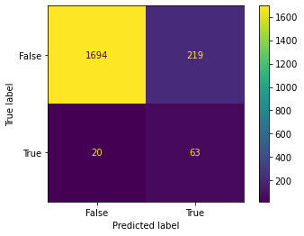

```python
# Plot confusion matrix
ConfusionMatrixDisplay.from_estimator(model, X_test, y_test);
```

```python
# Print classification report
print(classification_report(y_test, model.predict(X_test)))
```

```
              precision    recall  f1-score   support

       False       0.99      0.89      0.93      1913
        True       0.22      0.76      0.35        83

    accuracy                           0.88      1996
   macro avg       0.61      0.82      0.64      1996
weighted avg       0.96      0.88      0.91      1996
```

Although the overall accuracy of the model does not seem good if in a scenario where a company would like to know the best assertiveness on who is more likely to go bankrupt this model would be ideal since its recall value is much better than the previous model

# Communicating the Results

Sometimes it is interesting to save the best model so it is easier to share with a friend or colleague

```python
# Save model
with open("best_predict_model_bankrupcy.pkl", "wb") as f:
    pickle.dump(model, f)
```

```python
# Import your module
from predictor import make_predictions

# Generate predictions
y_test_pred = make_predictions(
    data_filepath="poland-bankruptcy-data-2009-mvp-features.json.gz",
    model_filepath="best_predict_model_bankrupcy.pkl",
)

print("predictions shape:", y_test_pred.shape)
y_test_pred.head()
```

```
predictions shape: (526,)
```

```
company_id
4     False
32    False
34     True
36    False
40     True
Name: bankrupt, dtype: bool
```